## Assignment 1- Decision Tree

### Submitted by- Anuj Bansal

### Roll no. - 2018201096 (Mtech CSE , 2nd Semester)

# Assignment Parts:

**Note: Please run all the cells**

- **Configure Attributes**
- **Part 1- Training and Prediction (Categorical)**
- **Part 2- Training and Prediction (Numerical)**
- **Part 3- Contrast the effectiveness of Misclassification rate, Gini, Entropy as impurity measures.**
- **Part 4- Generate Graphs (Training Data)**
- **Part 5- Generate Graphs (Validation/Training error Vs Depth/Number of nodes)**
- **Part 6- How decision tree is suitable handling missing values**

# Index:

1. Code Structure
2. Libraries Used
3. Configurable Features
4. Impurity Measures
5. Configuration and Utility Functions
6. Decision Tree Structure
   - For Categorical Features
   - For Numerical Features
7. Decision Tree training on categorical Features (Assignment- Part: 1)
   - Algorithm
   - Training and Prediction (Categorical)
8. Decision Tree training on categorical and numerical Features (Assignment- Part: 2)
   - Algorithm
   - Training and Prediction (Numerical)
9. Effectiveness of Misclassification rate, Gini, Entropy as impurity measures. (Assignment- Part: 3)
10. Visualise training data on a 2-dimensional plot. (Assignment- Part: 4)
    - Code
    - Generate Graphs
11. Validation error with respect to depth of decision tree (Assignment- Part: 5)
    - Code
    - Generate Graphs
12. How decision tree is suitable handling missing values (Assignment- Part: 6)
13. Scikit-Learn

## 1. Code Structure

The code for this assignment is modularized as a set of functions. Each of the function maps to some logical unit. This functions calls each other to perform the tasks specified in the assignment.

## 2. Libraries Used

We have used various python core libraries for this assignment:

1. **pandas**: For data manipulation and analysis.
2. **numpy**: To perform various mathematical operations on multi-dimensional arrays and matrices.
3. **matplotlib**: Plotting library to draw graphs.

```python
#import necessary packages
import pandas as pd
import numpy as np
import matplotlib.pyplot as plt
import matplotlib as mpl
```

## 3. Configurable Features

**Note: You can change this part as per your requirements**

The attributes/features in the training file used for training the decision tree can be either numerical or categorical.  
Prior to build the decision tree we need to know that which of these features are numerical (defined in a contineous range) and which are categorical (having discrete values)

As a part of our assigment following two lists are used to diffentiate between categorical and numerical features:

1. **cFeatures**: Containing column names of categorical features as per the training data.
2. **nFeatures**: Containing column names of numerical features as per the training data

```python
#Provide the column names of categorical attributes
cFeatures=['Work_accident','promotion_last_5years','sales','salary']

#Provide the column names of numerical attributes
nFeatures=['satisfaction_level','last_evaluation','number_project','average_montly_hours','time_spend_company']
```

## 4. Impurity Measures

A decision tree is built top-down from a root node and involves partitioning the data into subsets that contain instances with similar values (homogenous).  
To calculate this homogeneity there are various impurity measures we have used:

1. **Entropy:** $$ E(S) = -(qlog_2(q)+(1-q)log_2(1-q)$$
2. **Gini Index:** $$ E(S) = 2q(1-q)$$
3. **Misclassification rate:** $$ E(S) = min(q,(1-q))$$

```python
#function to calculate entropy
def entropy(q) :
    if q >= 1 or q <= 0:
        return 0
    return -( q*np.log2(q) + (1-q)*np.log2(1-q) )

#function to calculate Gini index
def gini(q) :
    return 2*q*(1-q)

#function to calculate Misclassification rate
def misClass(q) :
    return min(q,1-q)
```

## 5. Information Gain

The information gain is based on the decrease in impurity score after a dataset is split on an attribute. Constructing a decision tree is all about finding attribute that returns the largest "information gain/ impurity reduction" (i.e., the most homogeneous branches).

Steps to calculate information gain (considering entropy as the impurity measure):

1. Calculate entropy, E(S), of the target/ training label i.e. "employees left" as discussed above.
2. The dataset can be split on the different attributes. The entropy for each branch is calculated. Then it is added proportionally, to get the weighted entropy for the split. The resulting entropy is subtracted from target the entropy before the split. The result is the Information Gain, or decrease in entropy. Information Gain for attribute A: $$ InfoGain(S,A) = E(S) - I(S,A) = E(S) - \sum_{i \in Values(A)} \frac{|S_i|}{|S|}E(S_i)$$

### Calculating information gain for Categorical feature

Select the attribute which provide the largest information gain.

$ Best Categorical Attribute = max(InfoGain(S,A_i))$ $\forall A_i \in Attributes $

```python
#Function to calculate information gain of an Attribute
#Parameters :
    # data = Training Data
    # currentAttr = Categorical Attribute of which information Gain is calculated
    # impType = Impurity measure (entropy | gini | misClass) used to calculate information gain
    # targetAttr = Target Attribute (Class Label) default is "left" column
#Return :
    # Return the information gain of current Attribute with impurity type(entrop/gini/misclass)

def infoGain(data,currentAttr,impType,targetAttr="left") :

    totalRows = data.shape[0] #total Rows in data

    #Class label unique values [0,1] and their corresponding counts [x,y]
    targetValues, targetValuesCount = np.unique(data[targetAttr],return_counts=True)

    #Current Attribute unique values ex. ["low","medium","high"] and their corresponding counts [x,y,z]
    currentValues, currentValuesCount = np.unique(data[currentAttr],return_counts=True)

    targetEntropy = impType(targetValuesCount[0]/(totalRows)) #target Entropy

    weightedEntropy = 0
    intrinsic = 0

    data1 = data.values
    valueMap = { j:0 for j in currentValues} #ex . {"low":0, "medium":0, "high":0}

    i=0
    while(i < totalRows):
        if data1[i][keyValueMap[targetAttr]] == 0:
            valueMap[data1[i][keyValueMap[currentAttr]]] += 1
        i += 1

    for j,i in enumerate(currentValues):
        weightedEntropy += ( (currentValuesCount[j]/totalRows) * impType(valueMap[i]/currentValuesCount[j]) )

    informationGain = targetEntropy - weightedEntropy
    return informationGain
```

```python
#Function return best atrribute (having maximum information gain) with its information gain
#Parameters :
    # data = Training Data
    # cFeatures = Categorical Attributes list
    # impType = Impurity measure (entropy | gini | misClass) used to calculate information gain

#Return :
    # Tuple (best Attribute, Information gain)

def bestInfoGainFeature(data,cFeatures,impType):
    infGains = [infoGain(data,feature,impType) for feature in cFeatures]
    featureIndex = np.argmax(infGains)
    bestFeature = cFeatures[featureIndex]
    return (bestFeature,infGains[featureIndex])
```

### Calculating information gain for Numerical feature

Let we have numerical feature $$X=\{x_1,x_2,...x_n\}$$

Taking $x_1$ as a split point , calculate information gain of X on split $x_1$
$$ InfoGain(S,X=x_1) = E(S) - I(S,X=x_1) = E(S) - \sum_{i <= x_1 \space|\space i>x_1} \frac{|S_i|}{|S|}E(S_i)$$

Simlarly, $$ InfoGain(S,X=x_2) = E(S) - I(S,X=x_2) = E(S) - \sum_{i <= x_2 \space|\space i>x_2} \frac{|S_i|}{|S|}E(S_i)$$ $$.$$ $$.$$ $$ InfoGain(S,X=x_n) = E(S) - I(S,X=x_n) = E(S) - \sum_{i <= x_n \space|\space i>x_n} \frac{|S_i|}{|S|}E(S_i)$$

$$ InfoGain Numerical(S,X) = max(InfoGain(S,X=x_i)) \space\space\space \forall x_i \in X$$

$ Best Numerical Attribute = max(InfoGain Numerical(S,A_i))$ $\forall A_i \in Attributes $

```python
#Function return best split (having maximum information gain) for the atrribute having contineous values

#Parameters :
    # data = Training Data
    # currentAttr = Attribute (contineous value) of which information Gain and split is calculated
    # impType = Impurity measure (entropy | gini | misClass) used to calculate information gain
    # targetAttr = Target Attribute (Class Label) default is "left" column
#Return :
    # Tuple (best split value, Information gain)

def numericSplitInfoGain(data,currentAttr, impType,target="left"):
    totalRows = data.shape[0]

    #sort data on numerical attribute
    data = data.sort_values(by=currentAttr, ascending=True, inplace=False)

    data1 = data.values
    ones  = np.sum(data[target]) #count of left=1 in data
    zeros = totalRows-ones #count of left=0 in data

    targetEntropy=impType(ones/(totalRows))

    lableCountsForLess=[0,0]
    labelCountsForGreater=[0,0]

    bestSplit = 0
    mxInfoGain = -1
    i = 0
    currentIndex = keyValueMap[currentAttr]  #index of current Attribute
    targetIndex = keyValueMap[target]   #index of target Attribute
    while i < totalRows:
        numericValue = data1[i][currentIndex]
        checkClass = data1[i][targetIndex]
        if checkClass == 0:
            #count of target's zeros for currentAttr <= numericaval
            lableCountsForLess[0] += 1
        else:
            #count of target's ones for currentAttr <= numericaval
            lableCountsForLess[1] += 1

        #count of target's zeros for currentAttr > numericaval
        labelCountsForGreater[0] = zeros - lableCountsForLess[0]
        #count of target's ones for currentAttr > numericaval
        labelCountsForGreater[1] = ones - lableCountsForLess[1]

        if( i+1 != totalRows and data1[i+1][currentIndex] == numericValue):
            i += 1
            continue

        #count of datasets with currentAttr <= numeric
        recordsLessThanNumeric = np.sum(lableCountsForLess)
        #count of datasets with currentAttr > numeric
        recordsGreaterThanNumeric = np.sum(labelCountsForGreater)

        a=0
        b=0
        if recordsLessThanNumeric:
            a = (recordsLessThanNumeric/totalRows) * impType(lableCountsForLess[0]/recordsLessThanNumeric)
        if recordsGreaterThanNumeric:
            b = (recordsGreaterThanNumeric/totalRows)*impType(labelCountsForGreater[0]/recordsGreaterThanNumeric)

        weightedEntropy = a+b
        informationGain = (targetEntropy-weightedEntropy)

        if(informationGain >= mxInfoGain):
            mxInfoGain = informationGain
            bestSplit = numericValue
        i += 1
    return (bestSplit,mxInfoGain)
```

```python
#Function return best atrribute (amongst all attributes with contineous values) having maximum information gain
#Parameters :
    # data = Training Data
    # impType = Impurity measure (entropy | gini | misClass) used to calculate information gain
#Return :
    # Tuple (best Attribute, best split, Information gain)

def bestInfoGainFeNumeric(data,impType):
    mxinFo = 0
    split = 0
    resF = ""
    for feature in nFeatures:
        fInfoG = numericSplitInfoGain(data,feature,impType)
        if fInfoG[1] >= mxinFo:
            resF = feature
            split = fInfoG[0]
            mxinFo = fInfoG[1]
    return (resF,split,mxinFo)
```

## 6. Configuration and Utility Functions

### 6.1. config Function

There is one configuration function used , to set and initialize the necessary global variables.

- It shuffles and initializes the data frame corresponding to the train data file on given train data percentage.
- It also initialize the test data frame, given a test file.
- If no test file is provided then it initialize the validatation data frame as remaining datasets of train data file.

```python
#Function initialize the global variables useful for all the routines
#Parameters :
    # trainFile = Training Data File
    # trainDataPercent = Impurity type (entropy | gini | misClass) used to calculate information gain
    # testFile = Test File to predict
#Return : True/False corresponding to errorfree configuration

def config(trainFile,trainDataPercent,testFile=None):
    testData=None
    global isValidateData
    isValidateData=True
    global nodesCount
    nodesCount=0
    try:
        data=pd.read_csv(trainFile)
        data=data.sample(frac=1)
        try:
            if testFile:
                testData=pd.read_csv(testFile)
                isValidateData=False
        except:
            print("Error reading test data")
            return False
    except:
        print("Error reading training data")
        return False

    global keyValueMap
    keyValueMap={ j:i for i,j in enumerate(list(data.columns.values))}
    totalDataSets=len(data)
    trainDataSetCount=int(trainDataPercent*totalDataSets/100)

    global trainData
    trainData=data[:trainDataSetCount]

    global validateData
    if isValidateData:
        validateData=data[trainDataSetCount:]
    else:
        isValidateData=False
        validateData=testData
    return True
```

### 6.2.0 predict Function

This is an interface which prints the performance matrix, thereby predicting the target class label according to the decision tree classifier (categorical or numerical).

```python
#Function predict and print the performance measures of class predicted by classifier
# having maximum information gain
#Parameters :
    # Tree = Decision tree
    # dType= Decision tree type ("categorical")|("numerical")
    # trainDataPercent= Train data percent (1-100)
    # impType = Impurity type -String ("entropy" | "gini" | "misClass")
    # wannaReturn = Boolean
    # targetAttr = Target Attribute (Class Label) default is "left" column
#Return :
    # Performance matrix (if wannaReturn=True)

def predict(tree,dType,trainDataPercent,impType,wannaReturn=False,targetAttr="left"):
    if len(validateData)==0:
        print("No test/validate data found")
        return

    if dType=="categorical":
        pFunc=predictClassCategorical
    elif dType== "numerical":
        pFunc=predictClassNumerical
    else:
        print("Wrong Parameter",dType)
        return

    validateData1=validateData.to_dict(orient = "records")

    if isValidateData:
        count=0
        TP=0
        TN=0
        keyVMapVali={ j:i for i,j in enumerate(list(validateData.columns.values))}

        totalRows=len(validateData)
        totalN=np.sum(validateData[targetAttr])
        totalP=totalRows-totalN

        for i in range(len(validateData1)):
            known=validateData.iloc[i][keyVMapVali[targetAttr]]
            pred=pFunc(tree,validateData1[i])
            if known==pred:
                if known==0:
                    TP+=1
                else:
                    TN+=1
        FN=totalP-TP
        FP=totalN-TN
        recall=TP/(TP+FN)
        precision=TP/(TP+FP)
        accuracy=(TP+TN)/(totalRows)
        f1Val=2*recall*precision/(recall+precision)

        if wannaReturn:
            return (100*(FP+FN)/totalRows,accuracy,precision,recall,f1Val)
        print("=========================================================")
        print("My Classifier Results for ( ",dType," )")
        print("Trained on %d percent of Training data " %(trainDataPercent))
        print("Total DataSets: ",len(trainData)+totalRows)
        print("Training DataSets: ", len(trainData))
        print("Validation DataSets: ",totalRows)
        print("Impurity Measure: ",impType)
        print("Truelly Validated: ", (TP+TN))
        print("Falsely Validated: ", (FP+FN))
        print("=========================================================")
        print("Accuracy: ",accuracy)
        print("Precision: ",precision)
        print("Recall: ", recall)
        print("F1-Score: ", f1Val)

    else:
        validateData.loc[:,'predicted'] = pd.Series()
        predCol=validateData.columns.get_loc('predicted')
        for i in range(len(validateData1)):
            validateData.iloc[i,predCol] = pFunc(tree,validateData1[i])
        print("Class predicted successfully: check output.csv")
        validateData
        validateData.to_csv("output.csv")
```

## 7. Decision Tree Structure

### 7.1. For Categorical Features

We have visualized the decision tree as a `python dictionary`.  
The keys of the dictionary represents the decision nodes.  
The branches of the decision nodes are represented by another dictionary, having keys as all the possible labels(values) of that decision node.  
The value correspond to these labels can be either a subtree (another dictionary) or one of the possible value (0 or 1) of the target attibute.

$$\{"salary" : \{ "low" : \{"projectNumber" : ... \} , "high": 1 \} \}$$

### 7.1.2. For Numerical Features

When we have a categorical feature as a decision node we use the same structure for the decision node as discussed above.

But, when we have a numerical feature as a decision node, we need 2 branches, each branch is repesented by a python tuple:

1. First branch correspond to the datasets having value less than or equal to split value corresponding to that numerical feature.

$$(splitValue,True)$$

1. Second branch correspond to the datasets having value greater that split value for that numerical feature.

$$(splitValue,False)$$

1. The value correspond to these branches can be either a subtree (another dictionary) or one of the possible value (0 or 1) of the target attibute.

$$\{"satisfaction" : \{ (0.46,True) : \{"projectNumber" : ... \} , (0.46, False): 1 \} \}$$

## 8. Decision Tree training on categorical Features (Assignment- Part: 1)

### 8.1. Algorithm

**buildTreeCategorical(filteredDatasets=tainingData,Attributes,impurityType,depth=100,targetAttr="left"):**

**{**

```
Create a root node for the tree

Base Cases

    1. If all the filtered taining datasets have same value of target attribute (0 or 1) ,
       return that value.
    2. If number of predicting attributes is empty, then return the most common value of the target
       attribute in the filtered training datasets.
    3. If depth of the tree equals zero, then return the most common value of the target
       attribute in the filtered training datasets.

Otherwise Begin

    1. bestFeature ← Pick the attribute with maximum information gain amongst all categorical features.
    2. set the root = bestFeature
    3. Create a new tree branch with label 'maxi' which keeps the track of most common value of the target
       attribute at this level (Useful if missing values appears in test data during prediction)
    4. For each possible value, vi, of bestFeature,
       -Let filteredDatasets(vi) be the subset of filteredDatasets that have the value vi for bestFeature.
       -Add a new tree branch with label 'vi' below Root, corresponding to the test bestFeature = vi.
       -Below this new branch add the subtree
         buildTreeCategorical(filteredDatasets(vi),Attributes–{bestFeature},impurityType,depth,targetAttr)
End
Return Root
```

**}**

```python
#Function train the decision tree on taking attributes as categorical and return the tree node
#Parameters :
    # filterdData = train data which keeps on filtering according to algorithm.
    # cFeatures = list of catergorical attributes on which tree will be trained
    # impType = Impurity type- Function (entropy | gini | misClass) used to calculate information gain
    # targetAttr = Target Attribute (Class Label) default is "left" column
#Return :
    # root node of tree

def buildTreeCategorical(filterdData,cFeatures,impType,depth=100,targetAttr="left"):
    global nodesCount

    nodesCount+=1

    #check if data is pure i.e all tuples have exact 1 type of label
    if(len(np.unique(filterdData[targetAttr]))<=1):
        return np.unique(filterdData[targetAttr])[0]

    #check if all the categorical attributes had been used
    elif(len(cFeatures)==0):
        values,count=np.unique(filterdData[targetAttr],return_counts=True)
        return values[np.argmax(count)]

    if(depth==0):
        values,count=np.unique(filterdData[targetAttr],return_counts=True)
        return values[np.argmax(count)]

    #else grow the tree for all possible value of best feature
    #threby filtering the data on that value of best feature
    else:
        #find best feature
        #create a node with best feature and return it at the end
        #remove best feature from local list of features(cFeatures) for now
        #execute a for loop for all possible value of best feature (filtering on this value), and create a branch on
            #this value [best][value1] and receive the result of recursive call on this filtered data
        bestF=bestInfoGainFeature(filterdData,cFeatures, impType)[0]
        node={bestF:{}}
        cFeatures=[feature for feature in cFeatures if feature!=bestF]

        values,count=np.unique(filterdData[targetAttr],return_counts=True)
        node[bestF]["maxi"]=values[np.argmax(count)]
        for value in np.unique(filterdData[bestF]):
            #filter new datatable based on best feature [value]
            filteredData=filterdData.where(filterdData[bestF]==value).dropna()
            node[bestF][value]=buildTreeCategorical(filteredData,cFeatures,impType,depth-1)

    return node
```

Below function will predict the label of the target attribute for one test/validate dataset and return it. If some of the attribute's value is wrong or empty in that dataset then it will return the most frequently occured label of the target attibute at that level of filteration.

```python
def predictClassCategorical(tree,validateDataRow):
    dataCols=validateDataRow.keys()
    for key in dataCols:
        if key in tree.keys():
            try:
                temp=tree[key][validateDataRow[key]]
            except:
                return tree[key]["maxi"]
            if isinstance(temp,dict):
                return predictClassCategorical(temp,validateDataRow)
            else:
                return temp
```

```python
#Function calls build tree function and predict function
#Parameters :
    # trainFile = Training Data File
    # trainDataPercent = Impurity type (entropy | gini | misClass) used to calculate information gain
    # impType = Impurity type- Function (entropy | gini | misClass) used to calculate information gain
    # testFile = Test File to predict
#Return : performance matrix needed

def trainAndTestCategorical(trainFile,trainDataPercent,impType,testFile=None):
    if not(config(trainFile,trainDataPercent,testFile)):
        return
    tree=buildTreeCategorical(trainData,cFeatures,impType)
    return predict(tree,"categorical",trainDataPercent,impType.__name__)
```

### 8.2. Training and Prediction (Categorical)

Default it uses only 4 attributes to train the decision tree (categorial only). (You can configure them **Configure Attributes**)

`['Work_accident','promotion_last_5years','sales','salary']`

You can pass following parameters in order:

- Param1 : Training Data file
- Param2 : Training Data (percent to train on) Ex. 80 means TrainingData=80% and ValidationData=20% (remaining data)
- Param3 : Impurity type, possible values: `entropy , gini, misClass` **(Note: this must be given without quotes)**
- Param4 (optional) : testData file (if provided then it will train the data on the percentage provided and predict the class for test data under `column "predicted"` in a new file `"output.csv"` )

```python
#predict labels for test file
# trainAndTestCategorical("train.csv",80,entropy,"sample_test.csv")

#prints performance matrix on 20% validation data
trainAndTestCategorical("train.csv",80,entropy)
```

```
=========================================================
My Classifier Results for (  categorical  )
Trained on 80 percent of Training data
Total DataSets:  11238
Training DataSets:  8990
Validation DataSets:  2248
Impurity Measure:  entropy
Truelly Validated:  1710
Falsely Validated:  538
=========================================================
Accuracy:  0.7606761565836299
Precision:  0.7616926503340757
Recall:  0.9982486865148862
F1-Score:  0.8640727640222334
```

## 9. Decision Tree training on categorical and numerical Features (Assignment- Part: 2)

### 9.1. Algorithm

**buildTreeCatAndNum(filteredDatasets=tainingData,Attributes,impurityType,depth=100,parentDataMode,target="left"):**

**{**

```
Create a root node for the tree

Base Cases

1. If filtererd dataset get empty, then return the most common value of the target attribute in the
   parent filtered training datasets.
2. If all the filtered taining datasets have same value of target attribute (0 or 1) ,return that value.
3. If depth of the tree equals zero, then return the most common value of the target attribute in the
   filtered training datasets.


Otherwise If number of predicting attributes is empty:

1. bestFeature ← bestFeatureNumerical ← Pick the attribute with maximum information gain amongst all
   numerical features.
2. if Information gain of bestFeature=0, then return the most common value of the target attribute
   in the filtered training datasets.
3. Let x be the split value of the bestFeature.
4. Add a new tree branch with label '(x,True)' below Root, corresponding to the test bestFeature <= x.
5. Below this new branch add the subtree
   buildTreeCatAndNum(filteredDatasets(bestGFeature<=x),Attributes,impurityType,depth,parentMod,target)
6. Add a new tree branch with label '(x,False)' below Root, corresponding to the test bestFeature > x.
7. Below this new branch add the subtree
   buildTreeCatAndNum(filteredDatasets(bestGFeature>x),Attributes,impurityType,depth,parentMod,target)

Otherwise Begin

1. bestFeatureCategorical ← Pick the attribute with maximum information gain amongst all
   categorical attributes.
2. bestFeatureNumerical ← Pick the attribute with maximum information gain amongst all numerical attributes
3. Compare entropy for the bestFeatureCategorical and bestFeatureNumerical to get bestFeature.

4. If bestFeature is bestFeatureCatergorical
   -Create a new tree branch with label 'maxi' which keeps the track of most common value of the target
    attribute at this level (Useful if missing values appears in test data during prediction).

   -For each possible value, vi, of bestFeature,
    -Let filteredDatasets(vi) be the subset of filteredDatasets that have the value vi for bestFeature.
    -Add a new tree branch with label 'vi' below Root, corresponding to the test A = vi.
    -Below this new branch add the subtree
     buildTreeCatAndNum(filteredDataset(vi),Attributes–{bestFeature},impurityType,depth,parentMod,target)

5. else if bestFeature is bestFeatureNumerical on split x
   -Add a new tree branch with label '(x,True)' below Root, corresponding to the test bestFeature <= x.
   -Below this new branch add the subtree
    buildTreeCatAndNum(filteredDatasets(bestGFeature<=x),Attributes,impurityType,depth,parentMod,target)
   -Add a new tree branch with label '(x,False)' below Root, corresponding to the test bestFeature > x.
   -Below this new branch add the subtree
    buildTreeCatAndNum(filteredDatasets(bestGFeature>x),Attributes,impurityType,depth,parentMod,target)

End
Return Root
```

**}**

```python
#Function train the decision tree with categorical and numerical features  and return the tree node
#Parameters :
    # filterdData = train data which keeps on filtering according to algorithm.
    # cFeatures = list of catergorical attributes (unused categorical features)
    # impType = Impurity type (entropy | gini | misClass) used to calculate information gain
    # targetAttr = Target Attribute (Class Label) default is "left" column
    # Note: uses nFeatures i.e numerical features in utility methods
#Return :
    # root node of tree
def buildTreeCatAndNum(filteredData,cFeatures,impType,depth=100,parentDataMode=None,targetAttr="left"):
    global nodesCount

    nodesCount+=1

    # check if data is empty, if so, return the class of target i.e "left" appeared maximum in its parent data
    if len(filteredData)==0:
        return parentDataMode

    # check if data is pure i.e all tuples have exact 1 type of label, if so return it
    if(len(np.unique(filteredData[targetAttr]))==1):
        return np.unique(filteredData[targetAttr])[0]

    if(depth==0):
        values,count=np.unique(filteredData[targetAttr],return_counts=True)
        return values[np.argmax(count)]

    # check if all the categorical attributes had been used, (numerical split may be possible)
    if(len(cFeatures)==0):

            # best numerical Feature and its split value
            bestFNum=bestInfoGainFeNumeric(filteredData, impType)
            bestF=bestFNum[0] # best Feature
            split=bestFNum[1] # split value
            ig=bestFNum[2]    # information gain

            # to handle values approcing to zero i.e. like  1.1e-16
            if ig<=0.00000001:
                values,count=np.unique(filteredData[targetAttr],return_counts=True)
                return values[np.argmax(count)]

            node={bestF:{}}
            parentDataMode = np.unique(filteredData[targetAttr])[np.argmax(np.unique(filteredData[targetAttr],return_counts=True)[1])]
            node[bestF]["maxi"]=parentDataMode
            node[bestF][(split,True)]=buildTreeCatAndNum(filteredData.where(filteredData[bestF]<=split).dropna(),cFeatures,impType,depth-1,parentDataMode)
            node[bestF][(split,False)]=buildTreeCatAndNum(filteredData.where(filteredData[bestF]>split).dropna(),cFeatures,impType,depth-1,parentDataMode)
            return node;

    # if not all categorical attributes had been used
    else:

        # get best categorical attribute and its info gain
        bestFCate=bestInfoGainFeature(filteredData,cFeatures, impType)

        # get best numerical attribute and its info gain
        bestFNum=bestInfoGainFeNumeric(filteredData, impType)

        # target i.e "left" class appeared maximum number of times
        parentDataMode = np.unique(filteredData[targetAttr])[np.argmax(np.unique(filteredData[targetAttr],return_counts=True)[1])]
        ig=max(bestFCate[1],bestFNum[2])

        # to handle values approcing to zero i.e. like  1.1e-16
        if ig<=0.00000001:
            values,count=np.unique(filteredData[targetAttr],return_counts=True)
            return values[np.argmax(count)]

        # if infromation gain of categorical attribute >= infromation gain of numerical attribute
        if bestFCate[1]>=bestFNum[2]:
            bestF=bestFCate[0]
            node={bestF:{}}
            cFeatures=[feature for feature in cFeatures if feature!=bestF]

            values,count=np.unique(filteredData[targetAttr],return_counts=True)
            node[bestF]["maxi"]=values[np.argmax(count)]

            for value in np.unique(filteredData[bestF]):
                # filter data based on best feature [value] and create a branch on it
                # here branch is identified by direct value

                filteredData=filteredData.where(filteredData[bestF]==value).dropna()
                node[bestF][value]=buildTreeCatAndNum(filteredData,cFeatures,impType,depth-1,parentDataMode)
        else:
            bestF=bestFNum[0]
            split=bestFNum[1]
            node={bestF:{}}
            # create 2 branches on split value (<= and >) and filter data accordingly
            # here branch is identified by tuple
            node[bestF][(split,True)]=buildTreeCatAndNum(filteredData.where(filteredData[bestF]<=split).dropna(),cFeatures,impType,depth-1,parentDataMode)
            node[bestF][(split,False)]=buildTreeCatAndNum(filteredData.where(filteredData[bestF]>split).dropna(),cFeatures,impType,depth-1,parentDataMode)

    return node
```

Below function will predict the label of the target attribute for one test/validate dataset and return it. If some of the attribute's value is wrong or empty in that dataset then it will return the most frequently occured label of the target attibute at that level of filteration.

```python
def predictClassNumerical(tree,validateDataRow):
    dataCols=validateDataRow.keys()
    for key in dataCols:
        if key in tree.keys():
            temp=tree[key]
            val=validateDataRow[key]
            temp2=list(temp.keys())
            if(isinstance(temp2[0],tuple)):
                if val<=temp2[0][0]:
                    if isinstance(temp[temp2[0]],dict):
                        return predictClassNumerical(temp[temp2[0]],validateDataRow)
                    else:
                        return temp[temp2[0]]
                else:
                    if isinstance(temp[temp2[1]],dict):
                        return predictClassNumerical(temp[temp2[1]],validateDataRow)
                    else:
                        return temp[temp2[1]]
            else:
                try:
                    if isinstance(temp[val],dict):
                        return predictClassNumerical(temp[val],validateDataRow)
                    else:
                        return temp[val]
                except:
                    return temp["maxi"]
```

```python
#Function initialize the global variables useful for all the routines and training and prediction
#Parameters :
    # trainFile = Training Data File
    # trainDataPercent = Impurity type (entropy | gini | misClass) used to calculate information gain
    # impType = Impurity type- Function (entropy | gini | misClass) used to calculate information gain
    # testFile = Test File to predict
#Return : performance matrix if needed

def trainAndTestNumerical(trainFile,trainDataPercent,impType,testFile=None):
    if not(config(trainFile,trainDataPercent,testFile)):
        return
    tree=buildTreeCatAndNum(trainData,cFeatures,impType)
    return predict(tree,"numerical",trainDataPercent,impType.__name__)
```

### 9.2 Training and Prediction (Numerical)

Default it uses below attributes to train the decision tree . (You can configure them **Configure Attributes**)

**Categorical:** `['Work_accident','promotion_last_5years','sales','salary']`

**Numerical:** `['satisfaction_level','last_evaluation','number_project','average_montly_hours','time_spend_company']`

You can pass following parameters in order:

- Param1 : Training Data file
- Param2 : Training Data (percent to train on) Ex. 80 means TrainingData=80% and ValidationData=20% (remaining data)
- Param3 : Impurity type, possible values: `entropy , gini, misClass` **(Note: this must be given without quotes)**
- Param4 (optional) : testData file (if provided then it will train the data on the percentage provided and predict the class for test data under `column "predicted"` in a new file `"output.csv"` )

```python
#predict labels for test file
# trainAndTestNumerical("train.csv",80,entropy,"sample_test.csv")

#prints performance matrix on 20% validation data
trainAndTestNumerical("train.csv",80,entropy)
```

```
=========================================================
My Classifier Results for (  numerical  )
Trained on 80 percent of Training data
Total DataSets:  11238
Training DataSets:  8990
Validation DataSets:  2248
Impurity Measure:  entropy
Truelly Validated:  2199
Falsely Validated:  49
=========================================================
Accuracy:  0.978202846975089
Precision:  0.9739376770538244
Recall:  0.9982578397212544
F1-Score:  0.9859478061370806
```

## 10. Effectiveness of Misclassification rate, Gini, Entropy as impurity measures. (Assignment- Part: 3)

Here we will print the performance matrix ...

- After training our decision tree on numerical and categorical features taking entropy, gini , and misclassification as the impurity measure.
- And after training our decision tree on categorical only features taking entropy, gini , and misclassification as the impurity measure.

```python
print("--------------------------------------------------------------------------------------------")
print("Numerical and Categorical Features Classifier performance measures")
print("--------------------------------------------------------------------------------------------")
print()
trainAndTestNumerical("train.csv",80,entropy)
trainAndTestNumerical("train.csv",80,gini)
trainAndTestNumerical("train.csv",80,misClass)

print()
print("--------------------------------------------------------------------------------------------")
print("Categorical only Features Classifier performance measures")
print("--------------------------------------------------------------------------------------------")
print()
trainAndTestCategorical("train.csv",80,entropy)
trainAndTestCategorical("train.csv",80,gini)
trainAndTestCategorical("train.csv",80,misClass)
```

```
--------------------------------------------------------------------------------------------
Numerical and Categorical Features Classifier performance measures
--------------------------------------------------------------------------------------------

=========================================================
My Classifier Results for (  numerical  )
Trained on 80 percent of Training data
Total DataSets:  11238
Training DataSets:  8990
Validation DataSets:  2248
Impurity Measure:  entropy
Truelly Validated:  2198
Falsely Validated:  50
=========================================================
Accuracy:  0.9777580071174378
Precision:  0.9756649688737974
Recall:  0.9959560947429231
F1-Score:  0.9857061177815895
=========================================================
My Classifier Results for (  numerical  )
Trained on 80 percent of Training data
Total DataSets:  11238
Training DataSets:  8990
Validation DataSets:  2248
Impurity Measure:  gini
Truelly Validated:  2193
Falsely Validated:  55
=========================================================
Accuracy:  0.9755338078291815
Precision:  0.9780473714615829
Recall:  0.9900584795321637
F1-Score:  0.9840162743388551
=========================================================
My Classifier Results for (  numerical  )
Trained on 80 percent of Training data
Total DataSets:  11238
Training DataSets:  8990
Validation DataSets:  2248
Impurity Measure:  misClass
Truelly Validated:  2100
```

[output cut: 38 more lines]

```
F1-Score:  0.8657921291624622
=========================================================
My Classifier Results for (  categorical  )
Trained on 80 percent of Training data
Total DataSets:  11238
Training DataSets:  8990
Validation DataSets:  2248
Impurity Measure:  misClass
Truelly Validated:  1713
Falsely Validated:  535
=========================================================
Accuracy:  0.7620106761565836
Precision:  0.7620106761565836
Recall:  1.0
F1-Score:  0.8649330977026003
```

## 11. Visualise training data on a 2-dimensional plot. (Assignment- Part: 4)

### 11.1. Code

Plot a scatter graph between 2 attibutes having maximum inofrmation gain on training data i.e. `satisfaction_level and last_evaluation`.

```python
mpl.rcParams.update(mpl.rcParamsDefault)

def visualizeTrainingData(trainFile):
    data=pd.read_csv(trainFile)
    idx_1 = data.where(data["left"] == 1).dropna()
    idx_0 = data.where(data["left"] == 0).dropna()
    features=[feature for feature in data.columns.values if feature!="left"]
    length=2
    #uncomment below to plot graph between every possible attribute
#     length=len(features)
    for i in range(length):
        for j in range(i+1,length):
            plt.scatter(idx_0[features[i]],idx_0[features[j]],edgecolors='k',alpha=0.2,s=80,c='g',label='Not Left')
            plt.scatter(idx_1[features[i]],idx_1[features[j]],edgecolors='k',alpha=0.2,s=80,c='r',label='Left')
            plt.legend()
            plt.legend(loc=0)
            plt.xlabel(features[i])
            plt.ylabel(features[j])
            plt.show()
```

### 11.2. Generate Graphs

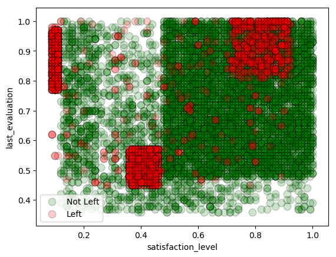

```python
visualizeTrainingData("train.csv")
```

## 12. Validation error with respect to depth of decision tree (Assignment- Part: 5)

In this part, we have plotted the lines graphs

- First line graph shows how the validation error percentage varies with depth of the tree for training data and validation data.
- Second line graph shows how the validation error percentage varies with number of node of the tree for training data and validation data.
- Third line graph shows how will the various performance measures varies with the depth of the tree for validation data.

### 12.1. Code

```python
mpl.rcParams.update(mpl.rcParamsDefault)

def visualizeErrors(trainFile,trainDataPercent,classifier,impType):
    if classifier=="categorical":
        pFunc=buildTreeCategorical
    elif classifier== "numerical":
        pFunc=buildTreeCatAndNum
    else:
        print("Wrong Parameter",dType)
        return

    if not(config(trainFile,trainDataPercent,None)):
        return
    x=[[],[],[],[],[]]
    y=[[],[],[],[],[]]
    z=[[],[],[],[],[]]


    global nodesCount
    nodesList=[]

    global validateData
    myValidation=validateData

    for i in range(1,11):
        nodesCount=0
        tree=pFunc(trainData,cFeatures,impType,i)
        validateData=myValidation
        ans=predict(tree,classifier,trainDataPercent,impType,True)
        validateData=trainData
        ans2=predict(tree,classifier,trainDataPercent,impType,True)
        nodesList.append(nodesCount)
        for j in range(5):
            y[j].append(ans[j])
            z[j].append(ans2[j])
            x[j].append(i)

    plt.xlabel("Depth of Decision Tree")
    plt.plot(x[0], y[0],color="orange", linewidth=2.5, label="Validation Data")
    plt.plot(x[0], z[0],color="green", linewidth=2.5, label="Training Data")
    plt.legend()
    plt.ylabel("Validation Errors (in Percent)")
    plt.grid(True)
    plt.show()

    plt.xlabel("Number of Nodes in Decision Tree")
    plt.plot(nodesList, y[0],color="orange", linewidth=2.5,label="Validation Data")
    plt.plot(nodesList,z[0], color="green", linewidth=2.5, label="Training Data")
    plt.legend()
    plt.ylabel("Validation Errors (in Percent)")
    plt.grid(True)
    plt.show()

    plt.grid(True)
    plt.plot(x[2], y[2],color="orange", linewidth=3.5,label="Precision")
    plt.plot(x[1], y[1],color="green", linewidth=2.5,label="Accuracy")
    plt.plot(x[4], y[4],color="b", linewidth=2.5,label="F1-Score")
    plt.plot(x[3], y[3],color="m", linewidth=2.5,label="Recall")

    plt.legend(loc=4)
    plt.ylabel("Performance Measures")
    plt.grid(True)
    plt.show()
```

### 12.2. Generate Graphs

You can pass following parameters in order:

- Param1 : Training Data file
- Param2 : Training Data (percent to train on) Ex. 90 means TrainingData=90% and ValidationData=10% (remaining data)
- Param4 : Classifier Type ( "numerical" or "categorical")
- Param4 : Impurity type, possible values: entropy , gini, misClass **(Note: this must be given without quotes)**

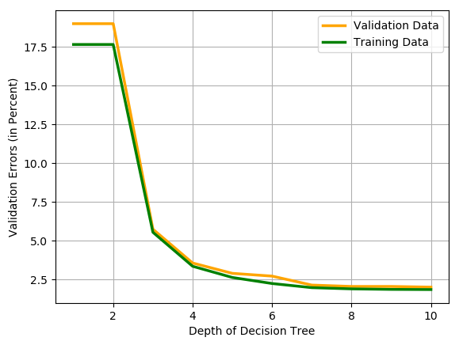

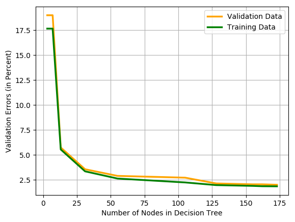

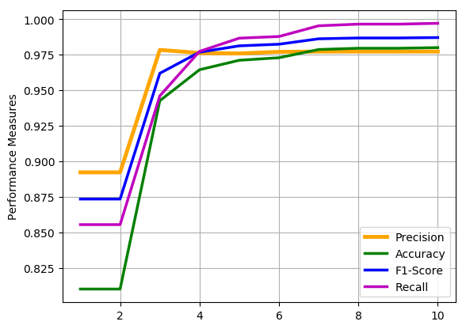

```python
visualizeErrors("train.csv",80,"numerical",entropy)
```

## 13. How decision tree is suitable handling missing values

At the time of predicting a class label for the target attribute ("left") of test dataset through our decision tree, we use the test dataset attribute-value pairs to find out the most appropriate class to which it belongs. We took the attribute that is present as a root in the tree and find out the branch corresponding to its value (in case with categorical attribute) to get a subtree. We recurse this step unless we will get a 0 or 1 (target value for the test dataset).

### Problem

#### Missing Branch due to missing value/ wrong value/ new value

If the test data set's attributes contains a Missing Value/ Wrong Value/ New Value , then out prediction algorithm will not be able to figure out the branch corresponding to that attribute node in our decision tree as such a data has never been encountered before. Thus a missing branch always encounter because of such values.

### Solution

**Solution-1 (Solution used in this assignment)**

To handle this problem, at each of the decision node we have created an `extra branch "maxi"`, which keeps a value (0 or 1) of target attribute based on the most frequently class occured in the subset of training dataset at that instance. Thus whenever a missing branch problem encountered, our prediction algorithm will genereate an exception and we will return the class stored by this "maxi" branch of that attribute whose value is missing/wrong/new.

This is an easy and fast solution but sometimes we may sacrifice a little bit of accuracy and prediciton.

**Solution-2**

The problem in above solution is that it is not utilizing the information provided by other attributes. In other words, lets say amongst 3 attributes A1,A2,A3 , only A1's value is missing, then if A1 attribute node arrives before A2 and A3 node in the tree then our algorithm will report a missing branch and instanly return the class stored by its "maxi" branch, without taking the A1's and A2's value into consideration.

Thus, in order to resolve this, whenever we will encounter a missing branch of an attribute node, we will go through its all the other branches with the path which have attributes values equal to the values of the remaining attributes to sum up to count of 0's and 1's, and at the end we will return the value/label with maximum count.

This solution imploves the prediction but incurr the computational cost to looks up all the branches.

## 14. Scikit Learn

This will show the comaprision of performance measures of out decision tree classifer with the classifiers provided by the scikit learn toolkit

```python
import sklearn
from sklearn.tree import DecisionTreeClassifier
from sklearn.metrics import accuracy_score
from sklearn.metrics import precision_recall_fscore_support
from sklearn import tree
from sklearn.model_selection import train_test_split
from sklearn.preprocessing import LabelEncoder
from sklearn.metrics import classification_report, confusion_matrix

def skLearn(trainFile,trainDataPercent,classifier,impType,testFile=None,target="left"):
    if trainDataPercent==100:
        print("No Validation data (Training percent should be less than 100)")
        return
    try:
        data=pd.read_csv(trainFile)
        data=data.sample(frac=1)
    except:
        print("Error reading train File")
        return
    le = LabelEncoder()
    X=None
    if classifier!="categorical" and classifier!="numerical":
        print("Invalid value of classifier argument (must be categorical or numerical)")
        return

    if "salary" in cFeatures or "salary" in nFeatures:
        data["salary"]=(le.fit_transform(data["salary"]))
    if "sales" in cFeatures or "sales" in nFeatures:
        data["sales"]=(le.fit_transform(data["sales"]))

    X=data.drop(target,axis=1)
    Y=data[target]

    if classifier=="categorical":
        X=X.drop(nFeatures,axis=1)


    trainX,testX,trainY,testY=train_test_split(X,Y,test_size=(100-trainDataPercent)/100,shuffle=False)
    tree = DecisionTreeClassifier(criterion = impType)
    tree.fit(trainX, trainY)
    y_pred = tree.predict(testX)
    matrix=precision_recall_fscore_support(testY,y_pred,average="binary",pos_label=0)
    confMat=confusion_matrix(testY,y_pred)
    print("=======================================================")
    print("Scikit Learn Results for ( ",classifier," )")
    print("Trained on %d percent of Training data " %(trainDataPercent))
    print("Total DataSets: ",len(data))
    print("Training DataSets: ",int(len(data)*(trainDataPercent/100)+0.5))
    print("Validation DataSets: ",int(len(data)*(1-trainDataPercent/100)+0.5))
    print("Impurity Measure: ",impType)
    print("Truelly Validated: ",confMat[0][0]+confMat[1][1])
    print("Falsely Validated: ",confMat[0][1]+confMat[1][0])
    print("=======================================================")
    print("Accuracy = ", accuracy_score(testY,y_pred))
    print("Precision = ", matrix[0])
    print("Recall = ", matrix[1])
    print("F1-Score = ", matrix[2])
```

### 13.1. Comparision of my algorithm with scikit-learn.

```python
trainAndTestNumerical("train.csv",80,entropy)
skLearn("train.csv",80,"numerical","entropy")

trainAndTestCategorical("train.csv",80,entropy)
skLearn("train.csv",80,"categorical","entropy")
```

```
=========================================================
My Classifier Results for (  numerical  )
Trained on 80 percent of Training data
Total DataSets:  11238
Training DataSets:  8990
Validation DataSets:  2248
Impurity Measure:  entropy
Truelly Validated:  2197
Falsely Validated:  51
=========================================================
Accuracy:  0.9773131672597865
Precision:  0.9751271905031091
Recall:  0.995958429561201
F1-Score:  0.985432733504713
=======================================================
Scikit Learn Results for (  numerical  )
Trained on 80 percent of Training data
Total DataSets:  11238
Training DataSets:  8990
Validation DataSets:  2248
Impurity Measure:  entropy
Truelly Validated:  2195
Falsely Validated:  53
=======================================================
Accuracy =  0.9764234875444839
Precision =  0.9870359457866824
Recall =  0.9818288393903869
F1-Score =  0.9844255069056714
=========================================================
My Classifier Results for (  categorical  )
Trained on 80 percent of Training data
Total DataSets:  11238
Training DataSets:  8990
Validation DataSets:  2248
Impurity Measure:  entropy
Truelly Validated:  1708
Falsely Validated:  540
=========================================================
Accuracy:  0.7597864768683275
Precision:  0.7600178094390027
Recall:  0.9994145199063232
F1-Score:  0.8634294385432473
=======================================================
Scikit Learn Results for (  categorical  )
Trained on 80 percent of Training data
Total DataSets:  11238
Training DataSets:  8990
Validation DataSets:  2248
Impurity Measure:  entropy
Truelly Validated:  1680
Falsely Validated:  568
=======================================================
Accuracy =  0.7473309608540926
Precision =  0.7474387527839643
Recall =  0.9994044073853484
F1-Score =  0.8552497451580021
```